# Project: Identify Customer Segments

In this project, you will apply unsupervised learning techniques to identify segments of the population that form the core customer base for a mail-order sales company in Germany. These segments can then be used to direct marketing campaigns towards audiences that will have the highest expected rate of returns. The data that you will use has been provided by our partners at Bertelsmann Arvato Analytics, and represents a real-life data science task.

This notebook will help you complete this task by providing a framework within which you will perform your analysis steps. In each step of the project, you will see some text describing the subtask that you will perform, followed by one or more code cells for you to complete your work. **Feel free to add additional code and markdown cells as you go along so that you can explore everything in precise chunks.** The code cells provided in the base template will outline only the major tasks, and will usually not be enough to cover all of the minor tasks that comprise it.

It should be noted that while there will be precise guidelines on how you should handle certain tasks in the project, there will also be places where an exact specification is not provided. **There will be times in the project where you will need to make and justify your own decisions on how to treat the data.** These are places where there may not be only one way to handle the data. In real-life tasks, there may be many valid ways to approach an analysis task. One of the most important things you can do is clearly document your approach so that other scientists can understand the decisions you've made.

At the end of most sections, there will be a Markdown cell labeled **Discussion**. In these cells, you will report your findings for the completed section, as well as document the decisions that you made in your approach to each subtask. **Your project will be evaluated not just on the code used to complete the tasks outlined, but also your communication about your observations and conclusions at each stage.**

## $\color{red}{\text{Leo's comments}}$

- The below steps ( 0 - 1.2 ) have been "packaged" up in step 1.3: "clean_data" function.
- For future interations, please start from step 1.3

```python
# import libraries here; add more as necessary
import numpy as np
import pandas as pd
import matplotlib.pyplot as plt
import seaborn as sns

# magic word for producing visualizations in notebook
%matplotlib inline

from pandas.api.types import is_string_dtype
from pandas.api.types import is_numeric_dtype
```

### Step 0: Load the Data

There are four files associated with this project (not including this one):

Each row of the demographics files represents a single person, but also includes information outside of individuals, including information about their household, building, and neighborhood. You will use this information to cluster the general population into groups with similar demographic properties. Then, you will see how the people in the customers dataset fit into those created clusters. The hope here is that certain clusters are over-represented in the customers data, as compared to the general population; those over-represented clusters will be assumed to be part of the core userbase. This information can then be used for further applications, such as targeting for a marketing campaign.

To start off with, load in the demographics data for the general population into a pandas DataFrame, and do the same for the feature attributes summary. Note for all of the `.csv` data files in this project: they're semicolon (`;`) delimited, so you'll need an additional argument in your [`read_csv()`](https://pandas.pydata.org/pandas-docs/stable/generated/pandas.read_csv.html) call to read in the data properly. Also, considering the size of the main dataset, it may take some time for it to load completely.

Once the dataset is loaded, it's recommended that you take a little bit of time just browsing the general structure of the dataset and feature summary file. You'll be getting deep into the innards of the cleaning in the first major step of the project, so gaining some general familiarity can help you get your bearings.

```python
# Load in the general demographics data.
azdias = pd.read_csv('Udacity_AZDIAS_Subset.csv', sep=';')
```

```python
# Load in the feature summary file.
feat_info = pd.read_csv('AZDIAS_Feature_Summary.csv', sep=';')
```

```python
# Check the structure of the data after it's loaded (e.g. print the number of rows and columns, print the first few rows).
azdias.describe()
```

|  | AGER_TYP | ALTERSKATEGORIE_GROB | ANREDE_KZ | CJT_GESAMTTYP | FINANZ_MINIMALIST | FINANZ_SPARER | FINANZ_VORSORGER | FINANZ_ANLEGER | FINANZ_UNAUFFAELLIGER | FINANZ_HAUSBAUER | ... | PLZ8_ANTG1 | PLZ8_ANTG2 | PLZ8_ANTG3 | PLZ8_ANTG4 | PLZ8_BAUMAX | PLZ8_HHZ | PLZ8_GBZ | ARBEIT | ORTSGR_KLS9 | RELAT_AB |
| --- | --- | --- | --- | --- | --- | --- | --- | --- | --- | --- | --- | --- | --- | --- | --- | --- | --- | --- | --- | --- | --- |
| count | 891221.000000 | 891221.000000 | 891221.000000 | 886367.000000 | 891221.000000 | 891221.000000 | 891221.000000 | 891221.000000 | 891221.000000 | 891221.000000 | ... | 774706.000000 | 774706.000000 | 774706.000000 | 774706.000000 | 774706.000000 | 774706.000000 | 774706.000000 | 794005.000000 | 794005.000000 | 794005.00000 |
| mean | -0.358435 | 2.777398 | 1.522098 | 3.632838 | 3.074528 | 2.821039 | 3.401106 | 3.033328 | 2.874167 | 3.075121 | ... | 2.253330 | 2.801858 | 1.595426 | 0.699166 | 1.943913 | 3.612821 | 3.381087 | 3.167854 | 5.293002 | 3.07222 |
| std | 1.198724 | 1.068775 | 0.499512 | 1.595021 | 1.321055 | 1.464749 | 1.322134 | 1.529603 | 1.486731 | 1.353248 | ... | 0.972008 | 0.920309 | 0.986736 | 0.727137 | 1.459654 | 0.973967 | 1.111598 | 1.002376 | 2.303739 | 1.36298 |
| min | -1.000000 | 1.000000 | 1.000000 | 1.000000 | 1.000000 | 1.000000 | 1.000000 | 1.000000 | 1.000000 | 1.000000 | ... | 0.000000 | 0.000000 | 0.000000 | 0.000000 | 1.000000 | 1.000000 | 1.000000 | 1.000000 | 0.000000 | 1.00000 |
| 25% | -1.000000 | 2.000000 | 1.000000 | 2.000000 | 2.000000 | 1.000000 | 3.000000 | 2.000000 | 2.000000 | 2.000000 | ... | 1.000000 | 2.000000 | 1.000000 | 0.000000 | 1.000000 | 3.000000 | 3.000000 | 3.000000 | 4.000000 | 2.00000 |
| 50% | -1.000000 | 3.000000 | 2.000000 | 4.000000 | 3.000000 | 3.000000 | 3.000000 | 3.000000 | 3.000000 | 3.000000 | ... | 2.000000 | 3.000000 | 2.000000 | 1.000000 | 1.000000 | 4.000000 | 3.000000 | 3.000000 | 5.000000 | 3.00000 |
| 75% | -1.000000 | 4.000000 | 2.000000 | 5.000000 | 4.000000 | 4.000000 | 5.000000 | 5.000000 | 4.000000 | 4.000000 | ... | 3.000000 | 3.000000 | 2.000000 | 1.000000 | 3.000000 | 4.000000 | 4.000000 | 4.000000 | 7.000000 | 4.00000 |
| max | 3.000000 | 9.000000 | 2.000000 | 6.000000 | 5.000000 | 5.000000 | 5.000000 | 5.000000 | 5.000000 | 5.000000 | ... | 4.000000 | 4.000000 | 3.000000 | 2.000000 | 5.000000 | 5.000000 | 5.000000 | 9.000000 | 9.000000 | 9.00000 |

8 rows × 81 columns

```python
azdias.shape
```

```
(891221, 85)
```

```python
azdias.head().append(azdias.tail())
```

|  | AGER_TYP | ALTERSKATEGORIE_GROB | ANREDE_KZ | CJT_GESAMTTYP | FINANZ_MINIMALIST | FINANZ_SPARER | FINANZ_VORSORGER | FINANZ_ANLEGER | FINANZ_UNAUFFAELLIGER | FINANZ_HAUSBAUER | ... | PLZ8_ANTG1 | PLZ8_ANTG2 | PLZ8_ANTG3 | PLZ8_ANTG4 | PLZ8_BAUMAX | PLZ8_HHZ | PLZ8_GBZ | ARBEIT | ORTSGR_KLS9 | RELAT_AB |
| --- | --- | --- | --- | --- | --- | --- | --- | --- | --- | --- | --- | --- | --- | --- | --- | --- | --- | --- | --- | --- | --- |
| 0 | -1 | 2 | 1 | 2.0 | 3 | 4 | 3 | 5 | 5 | 3 | ... | NaN | NaN | NaN | NaN | NaN | NaN | NaN | NaN | NaN | NaN |
| 1 | -1 | 1 | 2 | 5.0 | 1 | 5 | 2 | 5 | 4 | 5 | ... | 2.0 | 3.0 | 2.0 | 1.0 | 1.0 | 5.0 | 4.0 | 3.0 | 5.0 | 4.0 |
| 2 | -1 | 3 | 2 | 3.0 | 1 | 4 | 1 | 2 | 3 | 5 | ... | 3.0 | 3.0 | 1.0 | 0.0 | 1.0 | 4.0 | 4.0 | 3.0 | 5.0 | 2.0 |
| 3 | 2 | 4 | 2 | 2.0 | 4 | 2 | 5 | 2 | 1 | 2 | ... | 2.0 | 2.0 | 2.0 | 0.0 | 1.0 | 3.0 | 4.0 | 2.0 | 3.0 | 3.0 |
| 4 | -1 | 3 | 1 | 5.0 | 4 | 3 | 4 | 1 | 3 | 2 | ... | 2.0 | 4.0 | 2.0 | 1.0 | 2.0 | 3.0 | 3.0 | 4.0 | 6.0 | 5.0 |
| 891216 | -1 | 3 | 2 | 5.0 | 1 | 4 | 2 | 5 | 4 | 4 | ... | 3.0 | 2.0 | 0.0 | 0.0 | 1.0 | 2.0 | 3.0 | NaN | NaN | NaN |
| 891217 | -1 | 2 | 1 | 4.0 | 3 | 3 | 3 | 2 | 2 | 3 | ... | 1.0 | 3.0 | 3.0 | 2.0 | 4.0 | 5.0 | 3.0 | 4.0 | 6.0 | 5.0 |
| 891218 | -1 | 2 | 2 | 4.0 | 2 | 4 | 2 | 5 | 4 | 3 | ... | 4.0 | 2.0 | 0.0 | 0.0 | 1.0 | 3.0 | 4.0 | 2.0 | 2.0 | 3.0 |
| 891219 | -1 | 1 | 1 | 3.0 | 1 | 5 | 3 | 5 | 5 | 5 | ... | 1.0 | 4.0 | 3.0 | 1.0 | 5.0 | 1.0 | 1.0 | 4.0 | 7.0 | 5.0 |
| 891220 | -1 | 4 | 1 | 1.0 | 4 | 2 | 5 | 2 | 1 | 5 | ... | 3.0 | 3.0 | 1.0 | 0.0 | 1.0 | 4.0 | 4.0 | 3.0 | 4.0 | 5.0 |

10 rows × 85 columns

```python
#check the feature summary
feat_info[feat_info['attribute']=='CAMEO_DEUG_2015']
```

|  | attribute | information_level | type | missing_or_unknown |
| --- | --- | --- | --- | --- |
| 57 | CAMEO_DEUG_2015 | microcell_rr4 | categorical | [-1,X] |

```python
##spot-check the first attribute in "AGER_TYP" to get a sense of missing value [-1,0]
azdias['AGER_TYP'].value_counts()
```

```
-1    677503
 2     98472
 1     79802
 3     27104
 0      8340
Name: AGER_TYP, dtype: int64
```

```python
feat_info['information_level'].value_counts()
```

```
person            43
macrocell_plz8     8
building           7
household          7
microcell_rr3      6
region_rr1         5
postcode           3
microcell_rr4      3
community          3
Name: information_level, dtype: int64
```

```python
#Check the type of the features
feat_info['type'].value_counts()
```

```
ordinal        49
categorical    21
numeric         7
mixed           7
interval        1
Name: type, dtype: int64
```

```python
##try NOT to edit the raw data, work on the "coped version", as we might need to pull info from raw data table again
##by default we are using the "deep" copy, so that the two dfs are not "linked" after the copy.
##So any edit on the raw data should NOT affect the copied data
feat_info_copy=feat_info.copy(deep=True)
azdias_copy=azdias.copy(deep=True)
```

> **Tip**: Add additional cells to keep everything in reasonably-sized chunks! Keyboard shortcut `esc --> a` (press escape to enter command mode, then press the 'A' key) adds a new cell before the active cell, and `esc --> b` adds a new cell after the active cell. If you need to convert an active cell to a markdown cell, use `esc --> m` and to convert to a code cell, use `esc --> y`.

## Step 1: Preprocessing

### Step 1.1: Assess Missing Data

The feature summary file contains a summary of properties for each demographics data column. You will use this file to help you make cleaning decisions during this stage of the project. First of all, you should assess the demographics data in terms of missing data. Pay attention to the following points as you perform your analysis, and take notes on what you observe. Make sure that you fill in the **Discussion** cell with your findings and decisions at the end of each step that has one!

#### Step 1.1.1: Convert Missing Value Codes to NaNs

The fourth column of the feature attributes summary (loaded in above as `feat_info`) documents the codes from the data dictionary that indicate missing or unknown data. While the file encodes this as a list (e.g. `[-1,0]`), this will get read in as a string object. You'll need to do a little bit of parsing to make use of it to identify and clean the data. Convert data that matches a 'missing' or 'unknown' value code into a numpy NaN value. You might want to see how much data takes on a 'missing' or 'unknown' code, and how much data is naturally missing, as a point of interest.

**As one more reminder, you are encouraged to add additional cells to break up your analysis into manageable chunks.**

```python
# Identify missing or unknown data values per column/feature (axis=0), in order to convert them to NaN
azdias_copy.isnull().sum(axis=0)
```

```
AGER_TYP                      0
ALTERSKATEGORIE_GROB          0
ANREDE_KZ                     0
CJT_GESAMTTYP              4854
FINANZ_MINIMALIST             0
FINANZ_SPARER                 0
FINANZ_VORSORGER              0
FINANZ_ANLEGER                0
FINANZ_UNAUFFAELLIGER         0
FINANZ_HAUSBAUER              0
FINANZTYP                     0
GEBURTSJAHR                   0
GFK_URLAUBERTYP            4854
GREEN_AVANTGARDE              0
HEALTH_TYP                    0
LP_LEBENSPHASE_FEIN        4854
LP_LEBENSPHASE_GROB        4854
LP_FAMILIE_FEIN            4854
LP_FAMILIE_GROB            4854
LP_STATUS_FEIN             4854
LP_STATUS_GROB             4854
NATIONALITAET_KZ              0
PRAEGENDE_JUGENDJAHRE         0
RETOURTYP_BK_S             4854
SEMIO_SOZ                     0
SEMIO_FAM                     0
SEMIO_REL                     0
SEMIO_MAT                     0
SEMIO_VERT                    0
SEMIO_LUST                    0
                          ...
OST_WEST_KZ               93148
WOHNLAGE                  93148
CAMEO_DEUG_2015           98979
CAMEO_DEU_2015            98979
CAMEO_INTL_2015           98979
KBA05_ANTG1              133324
KBA05_ANTG2              133324
KBA05_ANTG3              133324
KBA05_ANTG4              133324
KBA05_BAUMAX             133324
KBA05_GBZ                133324
BALLRAUM                  93740
EWDICHTE                  93740
INNENSTADT                93740
GEBAEUDETYP_RASTER        93155
KKK                      121196
MOBI_REGIO               133324
ONLINE_AFFINITAET          4854
REGIOTYP                 121196
KBA13_ANZAHL_PKW         105800
PLZ8_ANTG1               116515
PLZ8_ANTG2               116515
PLZ8_ANTG3               116515
PLZ8_ANTG4               116515
PLZ8_BAUMAX              116515
PLZ8_HHZ                 116515
PLZ8_GBZ                 116515
ARBEIT                    97216
ORTSGR_KLS9               97216
RELAT_AB                  97216
Length: 85, dtype: int64
```

```python
##"missing or unkown" columns is in the "STR" type
type(feat_info_copy['missing_or_unknown'][0])
```

```
str
```

```python
##remove the square buckets
feat_info_copy['missing_or_unknown']=feat_info_copy['missing_or_unknown'].str.strip('[').str.strip(']')
#split the column by coma
feat_info_copy['missing_or_unknown']=feat_info_copy['missing_or_unknown'].str.split(',')

feat_info_copy[feat_info_copy['attribute']=='CAMEO_DEUG_2015']
```

|  | attribute | information_level | type | missing_or_unknown |
| --- | --- | --- | --- | --- |
| 57 | CAMEO_DEUG_2015 | microcell_rr4 | categorical | [-1, X] |

```python
#check the middle section with x or xx
feat_info_copy['missing_or_unknown'][56:65]
```

```
56        [-1]
57     [-1, X]
58        [XX]
59    [-1, XX]
60        [-1]
61        [-1]
62        [-1]
63        [-1]
64     [-1, 0]
Name: missing_or_unknown, dtype: object
```

```python
#to make sure the column is in "list" type
type(feat_info_copy['missing_or_unknown'][59])
```

```
list
```

```python
#BEFORE the conversion, value with each list should be "STR"
for i in feat_info_copy['missing_or_unknown'][59]:
    print (i,type(i))
```

```
-1 <class 'str'>
XX <class 'str'>
```

```python
def is_int(value):
  try:
    int(value)
    return True
  except ValueError:
    return False
```

```python
##convert from str to int
for c, i in enumerate(feat_info_copy['missing_or_unknown']):
    ls=[]
    for j in i:
        if is_int(j):
            ls.append(int(j))
        else:
            ls.append(j)
    print(ls)
    feat_info_copy['missing_or_unknown'].loc[c]=ls
```

```
[-1, 0]
[-1, 0, 9]
[-1, 0]
[0]
[-1]
[-1]
[-1]
[-1]
[-1]
[-1]
[-1]
[0]
['']
['']
[-1, 0]
[0]
[0]
[0]
[0]
[0]
[0]
[-1, 0]
[-1, 0]
[0]
[-1, 9]
[-1, 9]
[-1, 9]
[-1, 9]
[-1, 9]
[-1, 9]
[-1, 9]
[-1, 9]
[-1, 9]
[-1, 9]
[-1, 9]
[-1, 9]
[-1, 9]
[-1, 9]
[-1]
[-1]
```

[output cut: 30 more lines]

```
[-1, 0]
['']
['']
[-1, 0]
['']
[-1]
[-1]
[-1]
[-1]
[-1, 0]
[-1]
[-1]
[-1, 9]
[-1, 0]
[-1, 9]
```

```python
feat_info_copy['missing_or_unknown'].head(60)
```

```
0        [-1, 0]
1     [-1, 0, 9]
2        [-1, 0]
3            [0]
4           [-1]
5           [-1]
6           [-1]
7           [-1]
8           [-1]
9           [-1]
10          [-1]
11           [0]
12            []
13            []
14       [-1, 0]
```

[output cut: 46 more lines]

```python
##AFTER the conversion, value (except 'X' or 'XX') should be "INT" format
for i in feat_info_copy['missing_or_unknown'][59]:
    print (i,type(i))
```

```
-1 <class 'int'>
XX <class 'str'>
```

```python
##creat the below table, ready for the loop function to call upon
missing_value = feat_info_copy.set_index('attribute')['missing_or_unknown']
missing_value
```

```
attribute
AGER_TYP                    [-1, 0]
ALTERSKATEGORIE_GROB     [-1, 0, 9]
ANREDE_KZ                   [-1, 0]
CJT_GESAMTTYP                   [0]
FINANZ_MINIMALIST              [-1]
FINANZ_SPARER                  [-1]
FINANZ_VORSORGER               [-1]
FINANZ_ANLEGER                 [-1]
FINANZ_UNAUFFAELLIGER          [-1]
FINANZ_HAUSBAUER               [-1]
FINANZTYP                      [-1]
GEBURTSJAHR                     [0]
GFK_URLAUBERTYP                  []
GREEN_AVANTGARDE                 []
HEALTH_TYP                  [-1, 0]
LP_LEBENSPHASE_FEIN             [0]
LP_LEBENSPHASE_GROB             [0]
LP_FAMILIE_FEIN                 [0]
LP_FAMILIE_GROB                 [0]
LP_STATUS_FEIN                  [0]
LP_STATUS_GROB                  [0]
NATIONALITAET_KZ            [-1, 0]
PRAEGENDE_JUGENDJAHRE       [-1, 0]
RETOURTYP_BK_S                  [0]
SEMIO_SOZ                   [-1, 9]
SEMIO_FAM                   [-1, 9]
SEMIO_REL                   [-1, 9]
SEMIO_MAT                   [-1, 9]
SEMIO_VERT                  [-1, 9]
SEMIO_LUST                  [-1, 9]
                            ...
OST_WEST_KZ                    [-1]
WOHNLAGE                       [-1]
CAMEO_DEUG_2015             [-1, X]
CAMEO_DEU_2015                 [XX]
CAMEO_INTL_2015            [-1, XX]
KBA05_ANTG1                    [-1]
KBA05_ANTG2                    [-1]
KBA05_ANTG3                    [-1]
```

[output cut: 8 more lines]

```
MOBI_REGIO                       []
ONLINE_AFFINITAET                []
REGIOTYP                    [-1, 0]
KBA13_ANZAHL_PKW                 []
PLZ8_ANTG1                     [-1]
PLZ8_ANTG2                     [-1]
PLZ8_ANTG3                     [-1]
PLZ8_ANTG4                     [-1]
PLZ8_BAUMAX                 [-1, 0]
PLZ8_HHZ                       [-1]
PLZ8_GBZ                       [-1]
ARBEIT                      [-1, 9]
ORTSGR_KLS9                 [-1, 0]
RELAT_AB                    [-1, 9]
Name: missing_or_unknown, Length: 85, dtype: object
```

```python
#before the convert
print(azdias_copy['CAMEO_DEUG_2015'].unique())
print(azdias_copy['VERS_TYP'].unique())
print(azdias_copy['RELAT_AB'].unique())
```

```
[nan '8' '4' '2' '6' '1' '9' '5' '7' '3' 'X']
[-1  2  1]
[ nan   4.   2.   3.   5.   1.   9.]
```

```python
feat_info[feat_info['attribute']=='CAMEO_DEUG_2015']
```

|  | attribute | information_level | type | missing_or_unknown |
| --- | --- | --- | --- | --- |
| 57 | CAMEO_DEUG_2015 | microcell_rr4 | categorical | [-1,X] |

```python
feat_info_copy[feat_info_copy['attribute']=='CAMEO_DEUG_2015']
```

|  | attribute | information_level | type | missing_or_unknown |
| --- | --- | --- | --- | --- |
| 57 | CAMEO_DEUG_2015 | microcell_rr4 | categorical | [-1, X] |

```python
# convert from missing or unkown value (e.g. 0, 1, X) to np.nan
for col in azdias_copy.columns:
    azdias_copy[col] = azdias_copy[col].replace(missing_value.loc[col], np.nan)
```

```python
##AFTER the conversion, the value in 'X' shouldd have been replaced by np.nan
print(azdias_copy['CAMEO_DEUG_2015'].unique())
```

```
[nan '8' '4' '2' '6' '1' '9' '5' '7' '3']
```

#### Step 1.1.2: Assess Missing Data in Each Column

How much missing data is present in each column? There are a few columns that are outliers in terms of the proportion of values that are missing. You will want to use matplotlib's [`hist()`](https://matplotlib.org/api/_as_gen/matplotlib.pyplot.hist.html) function to visualize the distribution of missing value counts to find these columns. Identify and document these columns. While some of these columns might have justifications for keeping or re-encoding the data, for this project you should just remove them from the dataframe. (Feel free to make remarks about these outlier columns in the discussion, however!)

For the remaining features, are there any patterns in which columns have, or share, missing data?

## $\color{red}{\text{Leo's comments}}$

- I will define "column" as "feature" and "row" as "sample", all of which can ben used interchangebly in the code below

```python
missing_sample_per_feature=(azdias_copy.isnull().sum(axis=0)/len(azdias_copy)*100).sort_values(ascending= False)
```

```python
missing_sample_per_feature.head(20)
```

```
TITEL_KZ          99.757636
AGER_TYP          76.955435
KK_KUNDENTYP      65.596749
KBA05_BAUMAX      53.468668
GEBURTSJAHR       44.020282
ALTER_HH          34.813699
REGIOTYP          17.735668
KKK               17.735668
W_KEIT_KIND_HH    16.605084
KBA05_ANTG4       14.959701
KBA05_GBZ         14.959701
MOBI_REGIO        14.959701
KBA05_ANTG1       14.959701
KBA05_ANTG2       14.959701
KBA05_ANTG3       14.959701
PLZ8_GBZ          13.073637
PLZ8_HHZ          13.073637
PLZ8_BAUMAX       13.073637
PLZ8_ANTG4        13.073637
PLZ8_ANTG1        13.073637
dtype: float64
```

```python
missing_sample_per_feature.shape
```

```
(85,)
```

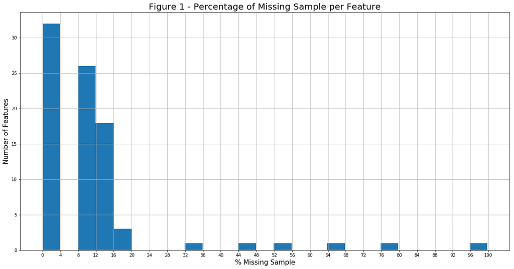

```python
# Investigate patterns in the amount of missing data in each column.
plt.figure(figsize=(20,10))
plt.hist(missing_sample_per_feature, bins=25);
plt.title("Figure 1 - Percentage of Missing Sample per Feature", fontsize=20);
plt.ylabel('Number of Features', fontsize=15);
plt.xlabel('% Missing Sample', fontsize=15);
plt.xticks(np.arange(0, 101, 4));
plt.grid()
```

```python
# Remove the outlier columns from the dataset. (You'll perform other data
# engineering tasks such as re-encoding and imputation later.)
outlier_col = pd.DataFrame(missing_sample_per_feature[missing_sample_per_feature>16]).index.tolist()
```

```python
outlier_col
```

```
['TITEL_KZ',
 'AGER_TYP',
 'KK_KUNDENTYP',
 'KBA05_BAUMAX',
 'GEBURTSJAHR',
 'ALTER_HH',
 'REGIOTYP',
 'KKK',
 'W_KEIT_KIND_HH']
```

```python
azdias_copy.shape[1]
```

```
85
```

```python
##drop the columns with high %missing data per col (>16%)
azdias_copy.drop(columns=outlier_col, inplace = True)
```

```python
azdias_copy.shape[1]
```

```
76
```

#### Discussion 1.1.2: Assess Missing Data in Each Column

## $\color{red}{\text{Leo's comments}}$

- Judging from Figure #1, I believe any feature/column with "%missingvalue > 16%" should be outlier and thus be removed)
- as a result, we manage to find 9 features that meet above criterion, all listed in "outlier_col"
- it would be truncated, reducing number of featurs from 85 to 76, as shown above

#### Step 1.1.3: Assess Missing Data in Each Row

Now, you'll perform a similar assessment for the rows of the dataset. How much data is missing in each row? As with the columns, you should see some groups of points that have a very different numbers of missing values. Divide the data into two subsets: one for data points that are above some threshold for missing values, and a second subset for points below that threshold.

In order to know what to do with the outlier rows, we should see if the distribution of data values on columns that are not missing data (or are missing very little data) are similar or different between the two groups. Select at least five of these columns and compare the distribution of values.

- You can use seaborn's [`countplot()`](https://seaborn.pydata.org/generated/seaborn.countplot.html) function to create a bar chart of code frequencies and matplotlib's [`subplot()`](https://matplotlib.org/api/_as_gen/matplotlib.pyplot.subplot.html) function to put bar charts for the two subplots side by side.
- To reduce repeated code, you might want to write a function that can perform this comparison, taking as one of its arguments a column to be compared.

Depending on what you observe in your comparison, this will have implications on how you approach your conclusions later in the analysis. If the distributions of non-missing features look similar between the data with many missing values and the data with few or no missing values, then we could argue that simply dropping those points from the analysis won't present a major issue. On the other hand, if the data with many missing values looks very different from the data with few or no missing values, then we should make a note on those data as special. We'll revisit these data later on. **Either way, you should continue your analysis for now using just the subset of the data with few or no missing values.**

```python
##to confirm we have already truncated 9 features due to far too many missing data
azdias_copy.shape[1]
```

```
76
```

```python
# How much data is missing in each row of the dataset?
missing_feature_per_sample=(azdias_copy.isnull().sum(axis=1)/azdias_copy.shape[1]*100)
```

```python
missing_feature_per_sample.shape
```

```
(891221,)
```

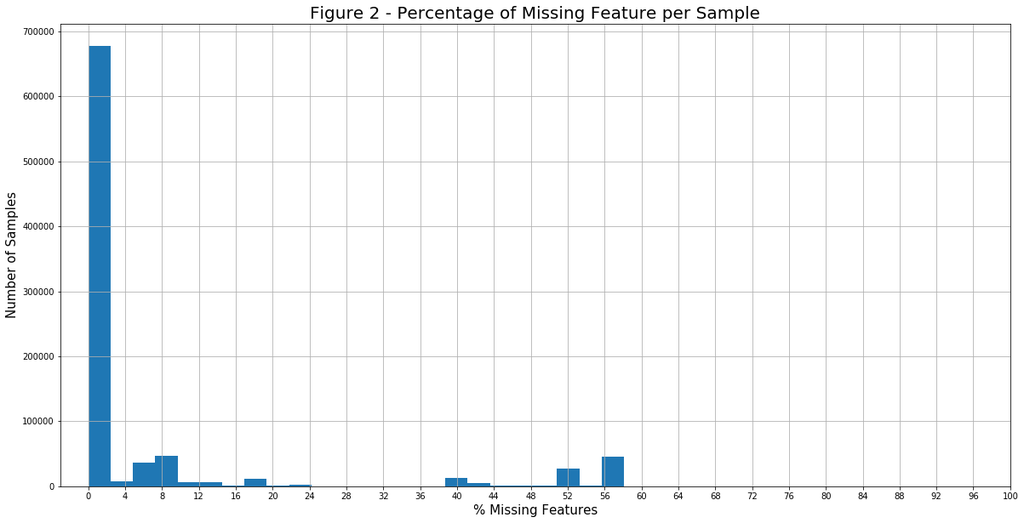

```python
# Investigate patterns in the amount of missing data in each column.
plt.figure(figsize=(20,10))
plt.hist(missing_feature_per_sample, bins=25);
plt.title("Figure 2 - Percentage of Missing Feature per Sample", fontsize=20);
plt.ylabel('Number of Samples', fontsize=15);
plt.xlabel('% Missing Features', fontsize=15);
plt.xticks(np.arange(0, 101, 4));
plt.grid()
```

```python
print(azdias_copy.shape,'\n')

print(missing_feature_per_sample.shape,'\n')

##combine two tables
azdias_copy= azdias_copy.join(pd.DataFrame(missing_feature_per_sample))

##to confirm the new columns has been added
print(azdias_copy.shape,'\n')
```

```
(891221, 76)

(891221,)

(891221, 77)
```

```python
##rename the last column
azdias_copy.rename(columns={azdias_copy.columns[-1]:'%MissingFeature'}, inplace = True)
```

```python
azdias_copy.head()
```

|  | ALTERSKATEGORIE_GROB | ANREDE_KZ | CJT_GESAMTTYP | FINANZ_MINIMALIST | FINANZ_SPARER | FINANZ_VORSORGER | FINANZ_ANLEGER | FINANZ_UNAUFFAELLIGER | FINANZ_HAUSBAUER | FINANZTYP | ... | PLZ8_ANTG2 | PLZ8_ANTG3 | PLZ8_ANTG4 | PLZ8_BAUMAX | PLZ8_HHZ | PLZ8_GBZ | ARBEIT | ORTSGR_KLS9 | RELAT_AB | %MissingFeature |
| --- | --- | --- | --- | --- | --- | --- | --- | --- | --- | --- | --- | --- | --- | --- | --- | --- | --- | --- | --- | --- | --- |
| 0 | 2.0 | 1 | 2.0 | 3 | 4 | 3 | 5 | 5 | 3 | 4 | ... | NaN | NaN | NaN | NaN | NaN | NaN | NaN | NaN | NaN | 52.631579 |
| 1 | 1.0 | 2 | 5.0 | 1 | 5 | 2 | 5 | 4 | 5 | 1 | ... | 3.0 | 2.0 | 1.0 | 1.0 | 5.0 | 4.0 | 3.0 | 5.0 | 4.0 | 0.000000 |
| 2 | 3.0 | 2 | 3.0 | 1 | 4 | 1 | 2 | 3 | 5 | 1 | ... | 3.0 | 1.0 | 0.0 | 1.0 | 4.0 | 4.0 | 3.0 | 5.0 | 2.0 | 0.000000 |
| 3 | 4.0 | 2 | 2.0 | 4 | 2 | 5 | 2 | 1 | 2 | 6 | ... | 2.0 | 2.0 | 0.0 | 1.0 | 3.0 | 4.0 | 2.0 | 3.0 | 3.0 | 5.263158 |
| 4 | 3.0 | 1 | 5.0 | 4 | 3 | 4 | 1 | 3 | 2 | 5 | ... | 4.0 | 2.0 | 1.0 | 2.0 | 3.0 | 3.0 | 4.0 | 6.0 | 5.0 | 0.000000 |

5 rows × 77 columns

```python
missing_feature_per_sample.shape
```

```
(891221,)
```

```python
#split  df by the threshold@20
azdias_good=azdias_copy[azdias_copy['%MissingFeature']<=20]
azdias_bad=azdias_copy[azdias_copy['%MissingFeature']>20]
```

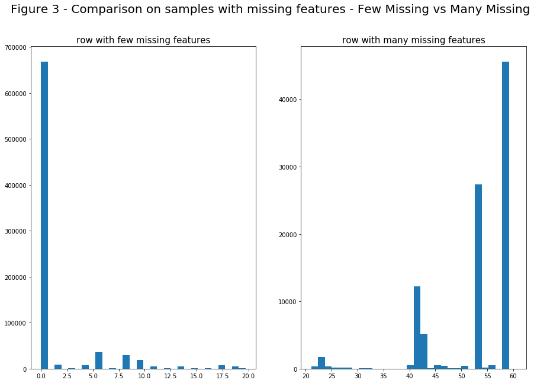

```python
fig,ax = plt.subplots(1,2,figsize=(15,10))
ax[0].hist(azdias_good['%MissingFeature'], bins = 30)
ax[0].set_title('row with few missing features', fontsize=15)

ax[1].hist(azdias_bad['%MissingFeature'], bins = 30)
ax[1].set_title('row with many missing features', fontsize=15)
fig.suptitle('Figure 3 - Comparison on samples with missing features - Few Missing vs Many Missing', fontsize=20)
plt.show()
```

```python
azdias_good.drop(columns=['%MissingFeature'],inplace=True)
azdias_bad.drop(columns=['%MissingFeature'],inplace=True)
```

```python
# Compare the distribution of values for at least five columns where there are
# no or few missing values, between the two subsets.
```

```python
##check the columns from "azdias_copy", which has 76 columns/features plus one extra in created variable called "%MissingValue"
## we will need to pick up RANDOMLY 5 features out of 76 the latter will be dropped for the below exercise)
feature_ls = azdias_copy.columns.tolist()[:-1]
len_feature = len(feature_ls)
len_feature
```

```
76
```

```python
##generate 5 random int for index
import random

rand_index = []

for i in range(0,5):
    x = random.randint(1,len_feature-1)
    rand_index.append(x)
```

```python
rand_index
```

```
[63, 25, 56, 29, 16]
```

```python
type(feature_ls)
```

```
list
```

```python
##pick up 5 random features from the subsection where there are not many missing data
random_feature_ls = [feature_ls[i] for i in rand_index]
```

```python
random_feature_ls
```

```
['MOBI_REGIO', 'SEMIO_MAT', 'KBA05_ANTG3', 'SEMIO_KULT', 'LP_FAMILIE_GROB']
```

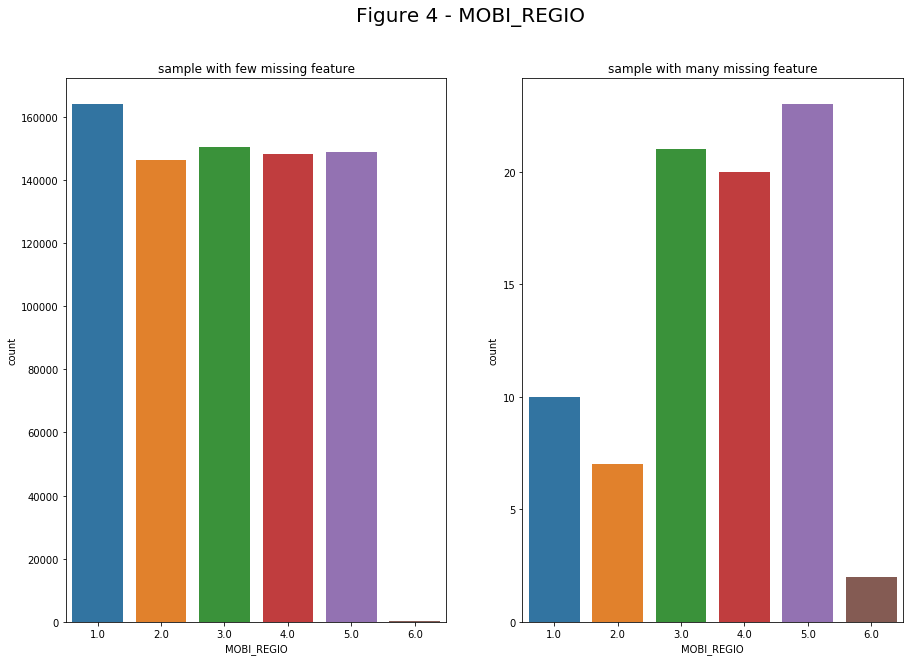

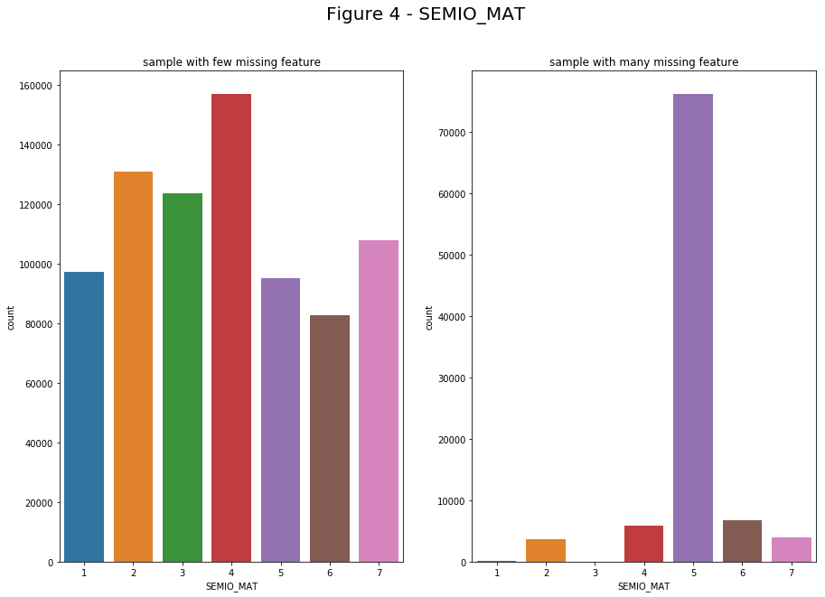

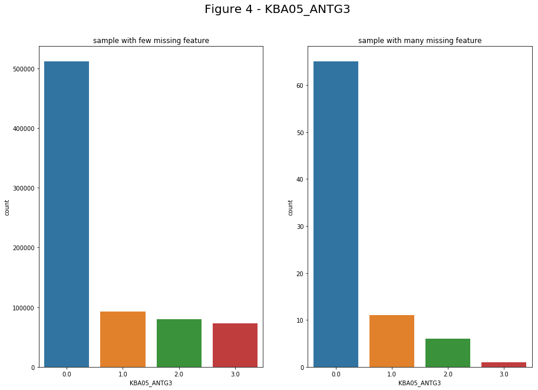

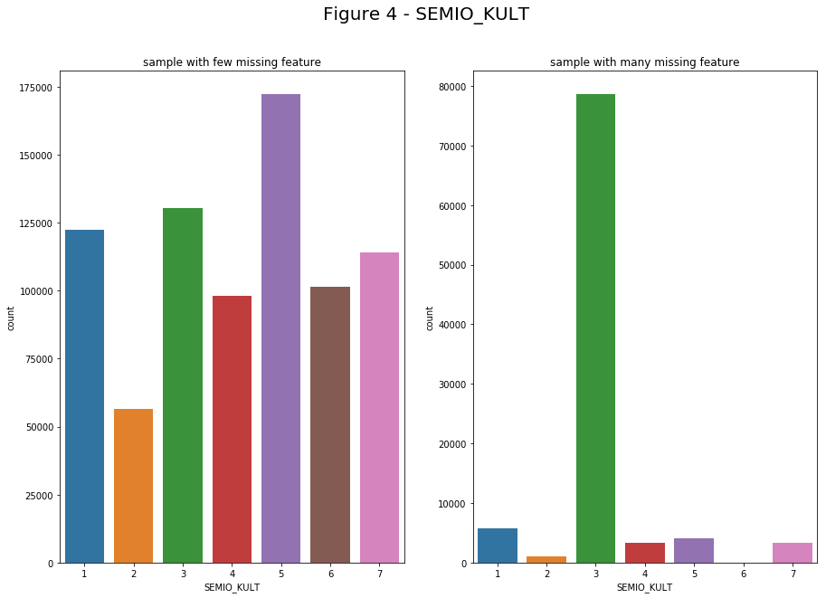

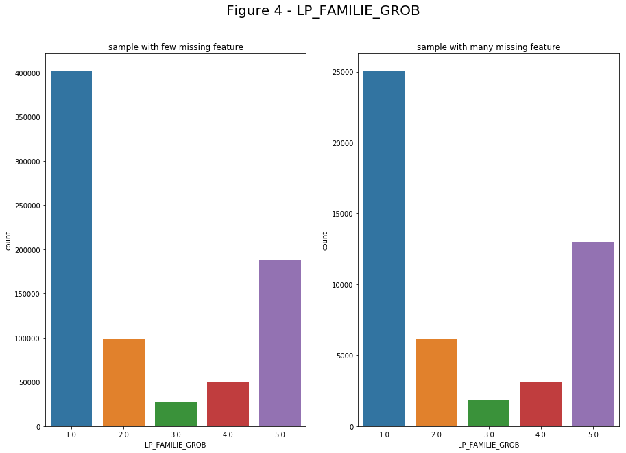

```python
for feature in random_feature_ls:

    fig = plt.figure(figsize=(15,10))
    ax1 = fig.add_subplot(121)
    ax1.title.set_text('sample with few missing feature')
    sns.countplot(azdias_good[feature])

    ax2 = fig.add_subplot(122)
    ax2.title.set_text('sample with many missing feature')
    sns.countplot(azdias_bad[feature])

    fig.suptitle("Figure 4 - " + feature, fontsize=20)
    plt.show()
```

```python
ratio = azdias_bad.shape[0]/ (azdias_bad.shape[0] + azdias_good.shape[0])
print('the number of rows with MANY (>20%) missing feature: ' + str(azdias_bad.shape[0]), '\n')
print('the number of rows with FEW (<=20%) missing feature: ' + str(azdias_good.shape[0]),'\n')
print('the ratio of "MANY" to "ALL" {0:.2%}'.format(ratio))
```

```
the number of rows with MANY (>20%) missing feature: 96286

the number of rows with FEW (<=20%) missing feature: 794935

the ratio of "MANY" to "ALL" 10.80%
```

#### Discussion 1.1.3: Assess Missing Data in Each Row

## $\color{red}{\text{Leo's comments}}$

- Judging from Figure #2, I believe any sample/rows with %missingFeature > 20% should be outlier
- those outliers account for about 10.8% of all rows ( = 96286 / 891221)
- my itention was to remove those outliers as they are only a small portion of the samples/rows
- however, by randomly picking up 5 features out of 76 (remember we truncated about 9 features out of 85, check "outlier_col"), I compare the histogram between
  - rows with MANY missing features (>20% * 76 feaures) and
  - rows with FEW missing features (<= 20% * 76 features)

**As shown in Figure #4, I DON'T think the data with many missing values looks IDENTICAL to the data with few or no missing values, the latter of which should be as "special". We'll revisit these data later on.**

### Step 1.2: Select and Re-Encode Features

Checking for missing data isn't the only way in which you can prepare a dataset for analysis. Since the unsupervised learning techniques to be used will only work on data that is encoded numerically, you need to make a few encoding changes or additional assumptions to be able to make progress. In addition, while almost all of the values in the dataset are encoded using numbers, not all of them represent numeric values. Check the third column of the feature summary (`feat_info`) for a summary of types of measurement.

- For numeric and interval data, these features can be kept without changes.
- Most of the variables in the dataset are ordinal in nature. While ordinal values may technically be non-linear in spacing, make the simplifying assumption that the ordinal variables can be treated as being interval in nature (that is, kept without any changes).
- Special handling may be necessary for the remaining two variable types: categorical, and 'mixed'.

In the first two parts of this sub-step, you will perform an investigation of the categorical and mixed-type features and make a decision on each of them, whether you will keep, drop, or re-encode each. Then, in the last part, you will create a new data frame with only the selected and engineered columns.

Data wrangling is often the trickiest part of the data analysis process, and there's a lot of it to be done here. But stick with it: once you're done with this step, you'll be ready to get to the machine learning parts of the project!

```python
# How many features are there of each data type?
#firstly remove the 9 outlier features due to too many missing values/samples/rows, all listed in outlier_col
feat_info_clean = feat_info_copy[~feat_info_copy['attribute'].isin(outlier_col)]
feat_info_clean['type'].value_counts()
```

```
ordinal        46
categorical    18
numeric         6
mixed           6
Name: type, dtype: int64
```

#### Step 1.2.1: Re-Encode Categorical Features

For categorical data, you would ordinarily need to encode the levels as dummy variables. Depending on the number of categories, perform one of the following:

- For binary (two-level) categoricals that take numeric values, you can keep them without needing to do anything.
- There is one binary variable that takes on non-numeric values. For this one, you need to re-encode the values as numbers or create a dummy variable.
- For multi-level categoricals (three or more values), you can choose to encode the values using multiple dummy variables (e.g. via [OneHotEncoder](http://scikit-learn.org/stable/modules/generated/sklearn.preprocessing.OneHotEncoder.html)), or (to keep things straightforward) just drop them from the analysis. As always, document your choices in the Discussion section.

```python
# Assess categorical variables: which are binary, which are multi-level, and
# which one needs to be re-encoded?
cat_feat_list_clean = feat_info_clean[feat_info_clean['type']=='categorical']['attribute']
cat_feat_list_clean.shape
```

```
(18,)
```

```python
azdias_good.head()
```

|  | ALTERSKATEGORIE_GROB | ANREDE_KZ | CJT_GESAMTTYP | FINANZ_MINIMALIST | FINANZ_SPARER | FINANZ_VORSORGER | FINANZ_ANLEGER | FINANZ_UNAUFFAELLIGER | FINANZ_HAUSBAUER | FINANZTYP | ... | PLZ8_ANTG1 | PLZ8_ANTG2 | PLZ8_ANTG3 | PLZ8_ANTG4 | PLZ8_BAUMAX | PLZ8_HHZ | PLZ8_GBZ | ARBEIT | ORTSGR_KLS9 | RELAT_AB |
| --- | --- | --- | --- | --- | --- | --- | --- | --- | --- | --- | --- | --- | --- | --- | --- | --- | --- | --- | --- | --- | --- |
| 1 | 1.0 | 2 | 5.0 | 1 | 5 | 2 | 5 | 4 | 5 | 1 | ... | 2.0 | 3.0 | 2.0 | 1.0 | 1.0 | 5.0 | 4.0 | 3.0 | 5.0 | 4.0 |
| 2 | 3.0 | 2 | 3.0 | 1 | 4 | 1 | 2 | 3 | 5 | 1 | ... | 3.0 | 3.0 | 1.0 | 0.0 | 1.0 | 4.0 | 4.0 | 3.0 | 5.0 | 2.0 |
| 3 | 4.0 | 2 | 2.0 | 4 | 2 | 5 | 2 | 1 | 2 | 6 | ... | 2.0 | 2.0 | 2.0 | 0.0 | 1.0 | 3.0 | 4.0 | 2.0 | 3.0 | 3.0 |
| 4 | 3.0 | 1 | 5.0 | 4 | 3 | 4 | 1 | 3 | 2 | 5 | ... | 2.0 | 4.0 | 2.0 | 1.0 | 2.0 | 3.0 | 3.0 | 4.0 | 6.0 | 5.0 |
| 5 | 1.0 | 2 | 2.0 | 3 | 1 | 5 | 2 | 2 | 5 | 2 | ... | 2.0 | 3.0 | 1.0 | 1.0 | 1.0 | 5.0 | 5.0 | 2.0 | 3.0 | 3.0 |

5 rows × 76 columns